# model_review_v4_ray

## 1. How the counterfactual actually works

The core idea: Take all 314 matches from the last six major tournaments exactly as they were played. For each match, *append* the stoppage time the referee should have added but didn’t, and ask one thing: would at least one more goal plausibly have dropped in? Average that probability over all 314 matches and you get the headline.

**Step 1. Measure the live football, then validate against outside numbers.** Every match comes from StatsBomb’s hand-coded event data: an analyst watches the video and logs every touch — pass, shot, throw-in, foul, card, sub, out of bounds — timestamped to the second. When the ball is dead, nothing gets logged, so a gap opens in the timestamps. Those gaps give me *ball-in-play*. I validate against the best available anchors: for 2022, my reconstruction reads **57:40 against Opta’s 58:04** (-24s); for 2018, **56:00 against Opta’s 54:50** (+70s), with FiveThirtyEight’s 55:18 in between (+42s).

My calculation relies on one global threshold: how long a silent gap must run before the ball counts as “dead.” Sweeping it from 12s to 30s, the anchors respond at different slopes (2018 ~2.3× more sensitive), so the residual is tournament-specific, not an offset one global setting could remove (full sweep in Appendix A). I therefore report ball-in-play with ~±1 minute per match of uncertainty, not a point estimate. Crucially, the headline figure doesn’t depend on getting ball-in-play exactly right: pushing the threshold across that entire 12s–30s range shifts the result by less than 0.1pp.

**Step 2. Separate stoppage *owed* from stoppage *played*, and validate that, too.** Stoppage actually played is easy: it’s whistle-to-whistle added time, read straight off the event clock. Stoppage *owed* is the hard part — I estimate it from the dead time the data can identify (goal celebrations, substitutions, cards, injuries, and the excess of slow restarts over a normal allowance), plus the dead-ball gaps the data independently confirms. The estimate is then calibrated against the one piece of independent ground truth that exists: **Nate Silver’s stopwatch measurement of all 32 World Cup 2018 matches**, where he recorded, by hand, both the stoppage that *should* have been added and the stoppage that *was*. My owed-stoppage estimator tracks his “should-have-been-added” column at **r = 0.825**, and my independently measured *played* clock tracks his “actually-played” column at **r = 0.992**, essentially exact (Figure 1).

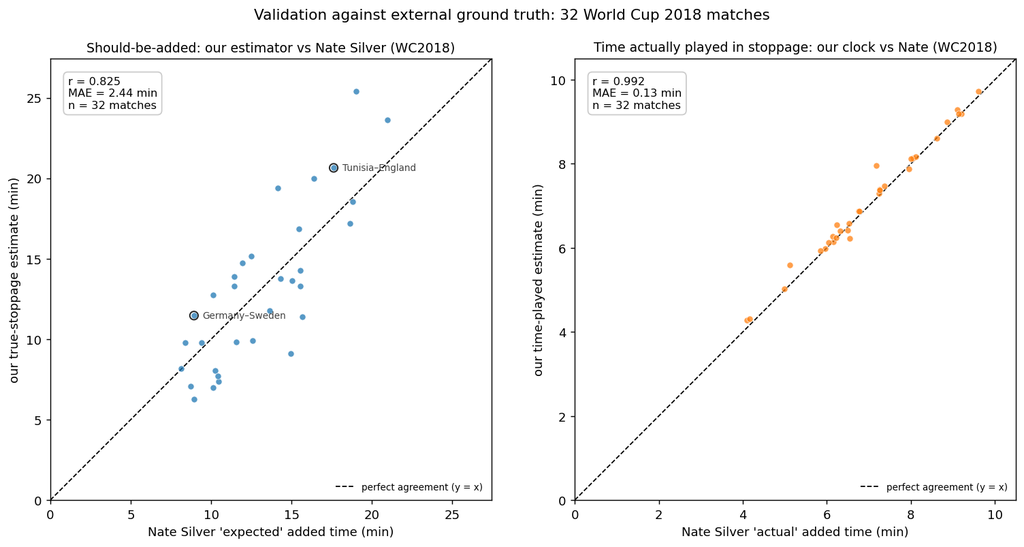

That gap is the engine of the whole piece. Across the 314 matches, owed stoppage averages about 17 minutes and played stoppage about 9, leaving roughly **8.6 omitted minutes per match** — positive in **97% of matches** — of which about **5.1 are live ball-in-play** once dead time is stripped out. Nate found the same pattern by hand in 2018: roughly half the owed stoppage simply never got played.

*What the rulebook actually requires — and where it goes quiet.* The Laws of the Game (Law 7) tell the referee to add on, at the end of each half, **all** the time lost to substitutions, injuries, goal celebrations, disciplinary action, VAR checks, and deliberate time-wasting. What the Laws never do is put a *number* on any of it. There is no stated allowance for how long a routine dead ball — a throw-in, a goal kick, a free kick — is permitted to take before the delay counts as time lost; whether a given restart was dragged out *in excess* is left entirely to the referee’s discretion. So to measure owed stoppage at all, you have to supply the thresholds the rulebook omits.

Nate Silver’s 2018 stopwatch study supplied exactly that: a fixed allowance for each routine restart, with anything beyond it counted as time lost. I adopt his table unchanged:

| Routine restart | Normal allowance (excess beyond this counts as owed) |
| --- | --- |
| Throw-in | 20 s |
| Goal kick | 30 s |
| Corner kick | 45 s |
| Free kick | 60 s |

So a throw-in that takes 50 seconds contributes 30 seconds of owed stoppage; one that takes 15 contributes nothing. Genuine stoppages — celebrations, substitutions, cards, injuries — are credited in full and separately; this table only governs the grey area the Laws hand to the referee’s judgment.

**Step 3 — Price the missing minutes.** Each omitted live minute gets a goal rate. Expected extra goals is just rate times minutes; the chance of *at least one* extra goal follows from the Poisson formula:

```
For each match, expected extra goals:
    μ  =  (1st-half goal rate)      × (omitted live 1st-half minutes)
        + (decayed 2nd-half rate)   × (omitted live 2nd-half minutes)

Probability of at least one extra goal:
    P(≥1)  =  1 − e^(−μ)

Headline  =  average of P(≥1) across all 314 matches
```

The one subtlety — and the subject of the next section — is the *rate*. Late-game minutes score faster than average, but I do **not** assume the missing minutes inherit that frantic pace. The second-half rate **decays** back toward the open-play rate as the hypothetical window grows. Run that over all 314 matches and the answer is **23.6%** of matches finishing with a different *scoreline* (95% confidence interval **20.6%–27.4%**). Stated separately and more strictly, the *result* — who actually wins or draws — flips in **12.1%** (CI 10.6%–14.2%). These two numbers mean different things and I keep them apart throughout: a scoreline can change without the winner changing, and 95 of the 314 matches were already decided by two or more goals at 90 minutes, so they can’t flip at all.

## Results and sensitivity — summary tables

*A one-page summary for quick scanning. Nothing here is new — it collects the headline number, its two kinds of uncertainty, and the full sensitivity grid from the analysis above and below.*

**Headline and spread.**

| Quantity | Value |
| --- | --- |
| **Headline — different scoreline (central)** | **23.6%** |
| 95% bootstrap confidence interval (sampling) | **[20.6%, 27.4%]** |
| Specification band — one modeling choice varied at a time | **21.1% – 26.1%** |
| Full envelope — all modeling choices varied jointly | **18.6% – 27.3%** |
| **Different *result*** — winner/draw actually changes | **12.1% [10.6%, 14.2%]** |
| Second-half-only variant (comparison, not the headline) | 16.0% [14.0%, 18.5%] |

*All figures are for the full match (first- and second-half stoppage combined), pooled across all 314 matches.*

The two bands are different objects and are kept apart throughout:

- **Sampling** uncertainty — the bootstrap CI **[20.6%, 27.4%]** (width 6.7 pts). It propagates finite goal counts and owed-stoppage estimator error: over B = 1000 draws, each goal-rate cell is redrawn from a Jeffreys–Gamma posterior and a shared estimator-error term `N(0, 3.06 min)` is split across the two halves.
- **Specification** uncertainty — how the headline moves as defensible modeling choices change, **one at a time** (the 21.1–26.1% band) or **all jointly** (the 18.6–27.3% envelope). This is the grid below.

*Scoreline vs result:* “different scoreline” = at least one extra goal anywhere in the omitted time (23.6%); “different result” = the winner or the draw actually flips (12.1%, strictly stronger — 95 of the 314 matches were ≥2 goals apart at 90′ and cannot flip).

**Specification sensitivities** — each modeling choice swept while the others are held at their central value (full match, all 314 matches; pts = percentage points of the headline):

[output not shown]

*Reading the grid* (λ = goals per live-minute, the Poisson rate that prices each omitted minute):

The one-at-a-time band (5.0 pts) is comparable to the sampling CI (6.7 pts), and the joint envelope (8.7 pts) only modestly exceeds it — neither kind of uncertainty dominates.

## 2. The obvious objection — and why the number survives it

*The first thing anyone with a quantitative bone says is: “you can’t price new minutes at the frantic end-of-game rate — teams wouldn’t keep scoring that fast.” They’re right, and the model is built around agreeing with them.*

Start by conceding the premise, because it’s true. Goals don’t arrive evenly: scoring climbs through a match, and second-half stoppage time is the most productive window on the field — **1.91× the open-play rate.**

| Window | Goals per live-minute | Goals (n) |
| --- | --- | --- |
| 2nd-half stoppage (the late-game peak) | **0.0816** | 73 |
| 1st-half stoppage | 0.0478 | 23 |
| Regulation open play (the floor) | **0.0427** | 675 |

The reason that peak rate is high isn’t anything about referees — it’s how the football is played late: a losing team throws everyone forward, defenses stretch, the game opens up. Which is exactly the objection in disguise: that rate is **endogenous to game state**. The minutes I observe at 0.0816 are *selected* for desperation, so pricing fresh, neutral minutes at that rate would overstate the result. I handle this two ways.

**First, the rate decays.** I don’t assume the late-game premium persists into the added minutes. Each marginal omitted second-half minute is priced on a curve that **decays from the observed 0.0816 back toward the open-play floor of 0.0427**, with a half-life I sweep from 2 to 8 minutes (central case: 4). The longer the hypothetical window, the closer each further minute is priced to ordinary open play. The first half keeps its observed rate, since the premium is concentrated in the second. Crucially, the *floor is open play* — so even under maximum decay, added minutes are never priced below match-average football. They’re still football.

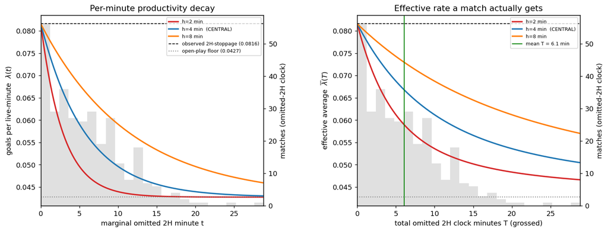

*Figure 2. Left: the per-minute rate assigned to an omitted second-half minute, decaying from the observed second-half-stoppage rate (0.0816, dashed) toward the open-play floor (0.0427, dotted), for half-lives of 2, 4 (central), and 8 minutes; the grey histogram is how many omitted minutes matches actually have. Right: the average rate a match effectively receives as a function of its total omitted minutes; the green line marks the typical match (about 6 minutes). Because most matches have modest windows, the effective rate sits well above the floor — but well below the raw peak.*

How much does this assumption move the answer? The whole decay band runs from **22.2%** (fastest decay) to **24.9%** (slowest) — a swing of under three points around the 23.6% headline. The objection is real, it’s priced in, and it moves the result by a couple of points, not by half.

**Second, the premium isn’t just a tied-game artifact.** If the high rate were purely a product of desperate, level matches, it should collapse when the match isn’t close. It doesn’t. Second-half stoppage scores at about the same rate whether the game is **level at 90 minutes (0.0886)** or **not (0.0786)** — the confidence intervals overlap heavily (Figure 3). So conditioning the whole model on score state at 90 minutes barely moves anything: the headline shifts from 23.6% to **23.4%**, a fifth of a point.

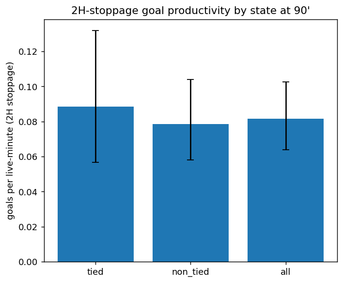

*Figure 3. Second-half-stoppage goal productivity split by the score state at 90 minutes — level, not level, and pooled. The rate is statistically indistinguishable across states (wide, overlapping intervals), which is why conditioning the model on game state moves the headline by only 0.2 points.*

**Third, this isn’t just an elimination-game artifact.** The other natural worry is stakes: maybe the late-game rate is inflated by win-or-go-home knockout matches, where a losing side has no tomorrow and empties the bench forward. It isn’t. Split the same second-half-stoppage window by match type and the rate is statistically flat — **group stage 0.0847** (56 goals / 660.8 live-minutes) against **elimination 0.0727** (17 goals / 233.7 live-minutes). The confidence intervals overlap heavily, and the point estimate actually leans *higher* in the group stage — the opposite of the “knockouts are more frantic” intuition (rate ratio 1.17, binomial p = 0.69, not significant; Figure 4). There’s no separate elimination effect to price, so the model keeps a single pooled rate rather than adding a stage term.

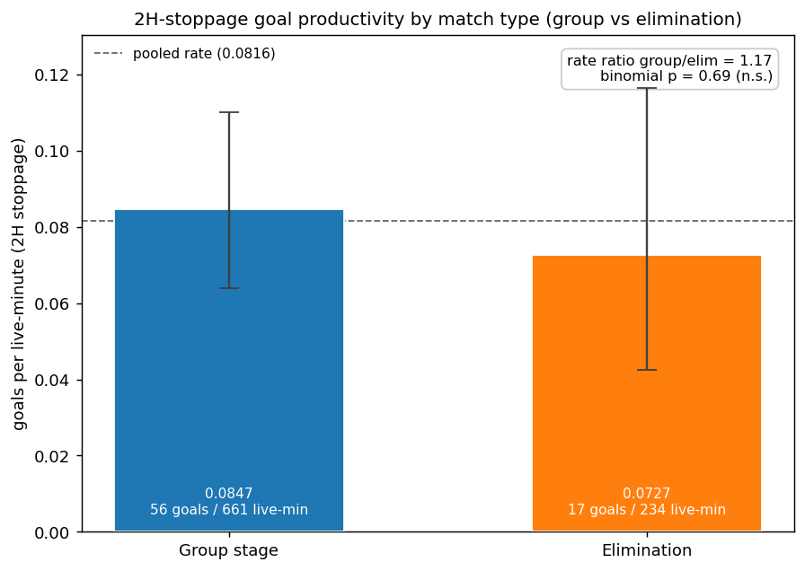

*Figure 4. Second-half-stoppage goal productivity split by match type — group stage versus elimination. The two rates are statistically indistinguishable (wide, overlapping intervals); the dashed line is the pooled rate. If anything the group stage scores slightly faster, the reverse of the high-stakes-knockout story — which is why the model prices added minutes with one pooled rate and no elimination covariate.*

## 3. Limitations

The Step-2 owed-stoppage estimator is anchored on World Cup 2018, i.e., the dead-gap crediting rule and the residual correction are calibrated to this tournament (restart allowances are fixed reference thresholds). Those choices are then frozen and applied unchanged to the other five tournaments.

This transfer crosses the a stoppage-time-related rule change that splits the tournaments in the dataset:

- The 2022 FIFA directive (Collina) told referees to add *all* time genuinely lost — celebrations, subs, injuries, penalties, VAR. Added-time boards jumped from ~7 min (PRE) to 11–12 (WC 2022).
- **PRE (115 matches):** WC 2018, Euro 2020. **POST (199):** WC 2022, Euro 2024, Copa América 2024, AFCON 2023.
- My one calibration tournament sits on the PRE side; the headline mostly lives on the POST side — where referees were explicitly told to behave differently.
- The extrapolation is large: estimated owed time in the five un-checked tournaments runs **~1.5–2× higher** than 2018’s (≈19 min POST vs 12.6; Copa and AFCON highest) — the model’s most exposed quantity is exactly where it can’t be verified.

## Appendix A. Ball-in-play knob robustness

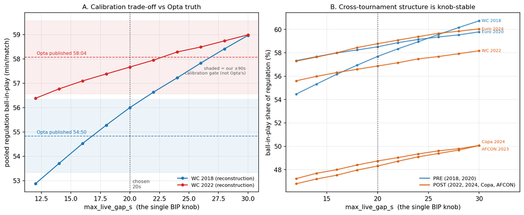